# Data Camp / Forecasting Using R - Chapter 4

Initialize and load the data

```r
library(ggplot2)
library(forecast)
library(fpp)
```

Chapter 4 of [Data Camp - Forecasting Using R](https://www.datacamp.com/courses/forecasting-using-r)

## Variance Stabilization

### Transformations for variance stabilization

- If the data show increasing variation as the level of the series increases, then a **transformation** can be useful.

Some common transformations are:

| What | Formula | When |
| --- | --- | --- |
| Square Root | $w_t = \sqrt{y_t}$ | $\downarrow$ |
| Cube Root | $w_t = \sqrt[3]{y_t}$ | Increasing |
| Log | $w_t = \log(y_t)$ | strength |
| Inverse | $w_t = \frac{-1}{y_t}$ | $\uparrow$ |

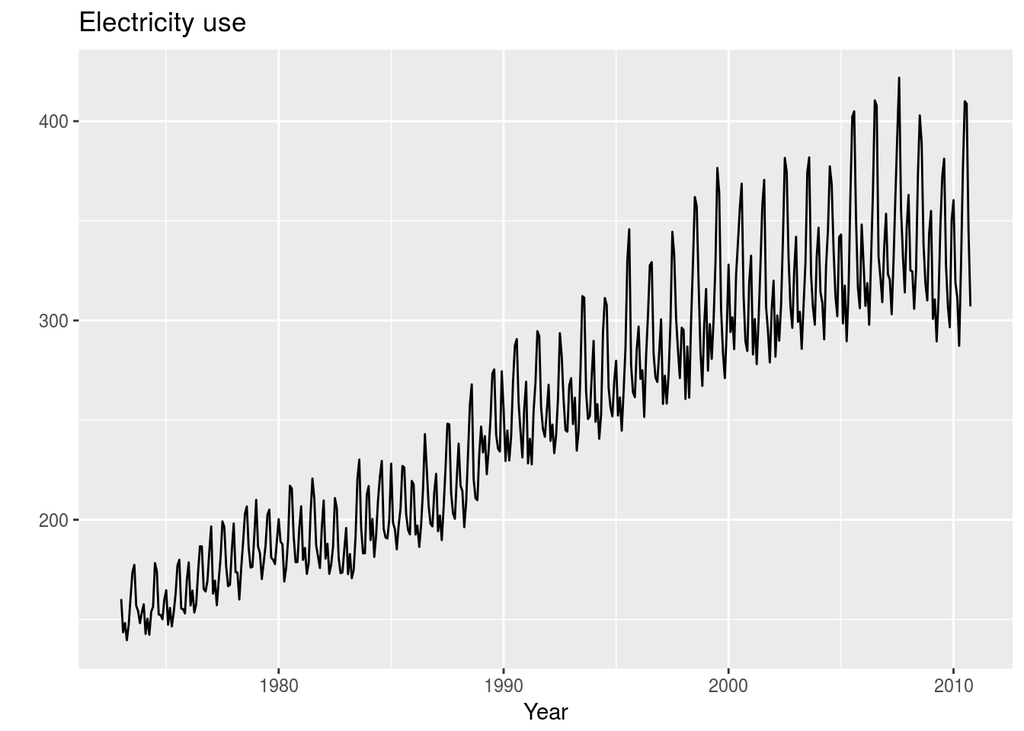

```r
autoplot(usmelec) +
  xlab("Year") +
  ylab("") +
  ggtitle("Electricity use")
```

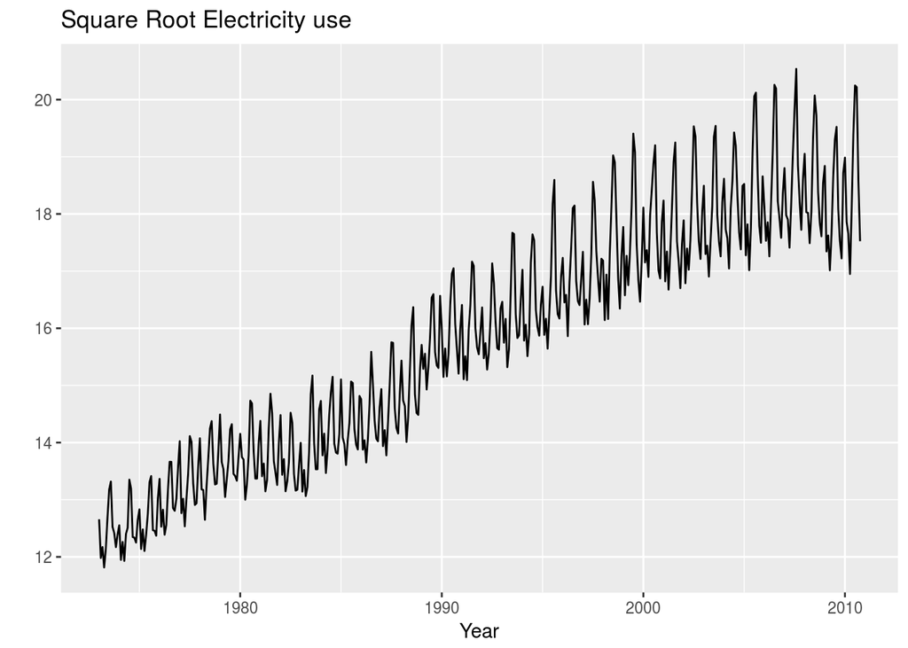

```r
autoplot(sqrt(usmelec)) +
  xlab("Year") +
  ylab("") +
  ggtitle("Square Root Electricity use")
```

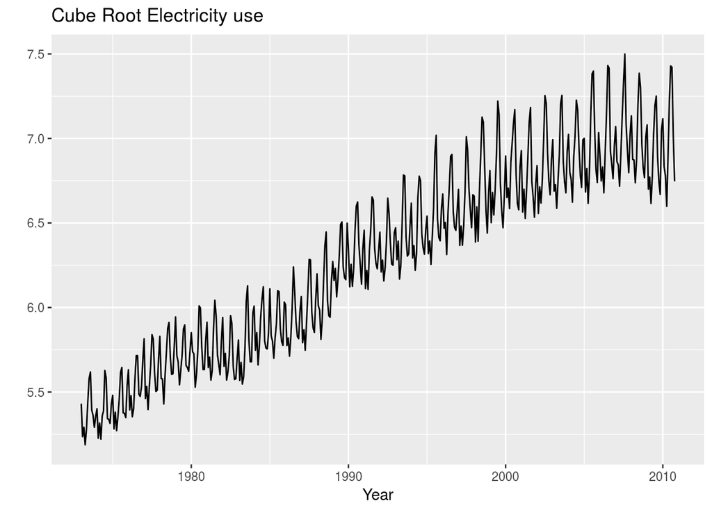

```r
autoplot(usmelec^0.3333333) +
  xlab("Year") +
  ylab("") +
  ggtitle("Cube Root Electricity use")
```

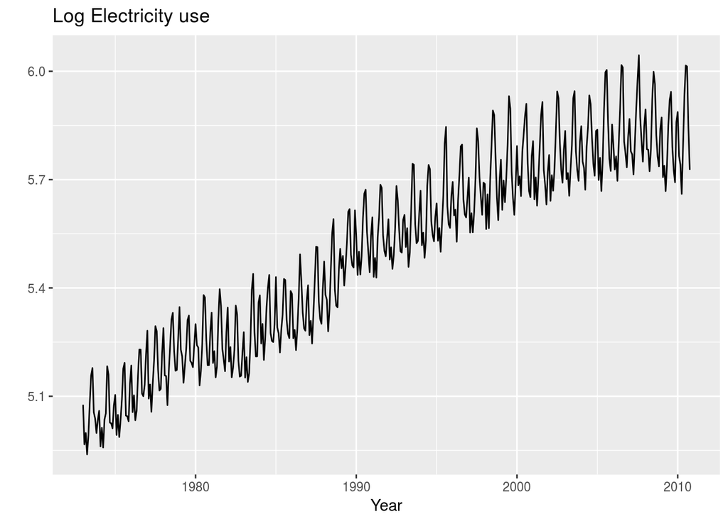

```r
autoplot(log(usmelec)) +
  xlab("Year") +
  ylab("") +
  ggtitle("Log Electricity use")
```

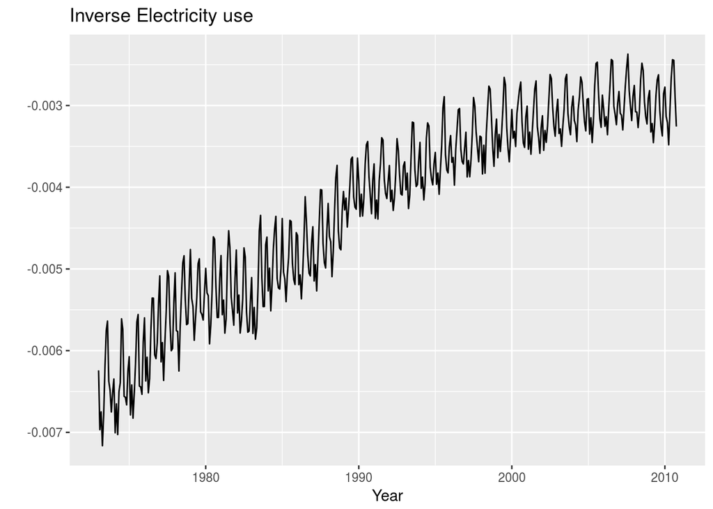

```r
autoplot((-1)/usmelec) +
  xlab("Year") +
  ylab("") +
  ggtitle("Inverse Electricity use")
```

## Box - Cox transformations

These are close to the previously described. The formula is

$w_t = \begin{cases}log(y_t) \\ \frac{y_t^{\lambda}}{\lambda} \end{cases}$ $\begin{eqnarray} \lambda = 0 \\ \lambda \neq 0 \end{eqnarray}$

- $\lambda = 1$ : No substanative transformation
- $\lambda = \frac{1}{2}$ : Square root plus linear transformation
- $\lambda = \frac{1}{3}$ : Cube root + linear transformation
- $\lambda = 0$ : Natural logarithm transformation
- $\lambda = -1$ : Inverse transformation

You can try different values for $\lambda$ or use the `BoxCox.lambda()` to get the approximate best value.

```r
BoxCox.lambda(usmelec)
```

```
## [1] -0.4772402
```

Once chosen simply add to modeling function.

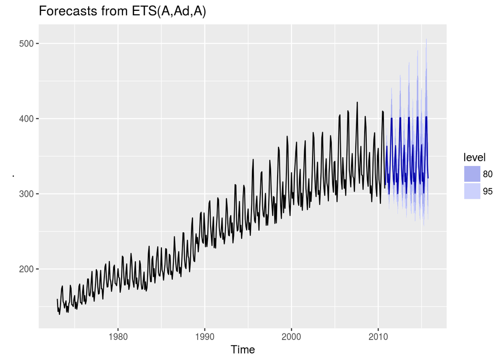

```r
usmelec %>%
  ets(lambda=(-0.477)) %>%
  forecast(h = 60) %>%
  autoplot()
```

For **ETS** models you don’t **NEED** to figure out the $\lambda$ but for **ARIMA** you will.

Here is an example where the sesonal data was **diff**ed out and then the it was smoothed by a second `diff()` call to get the non-seasonal variation out.

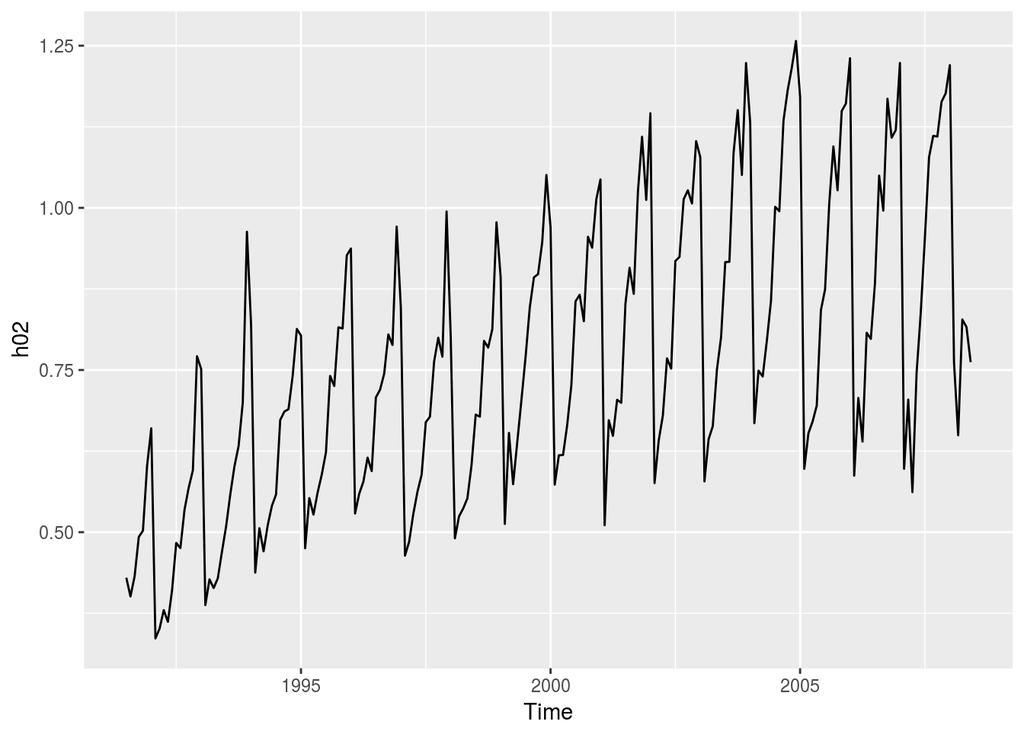

```r
autoplot(h02)
```

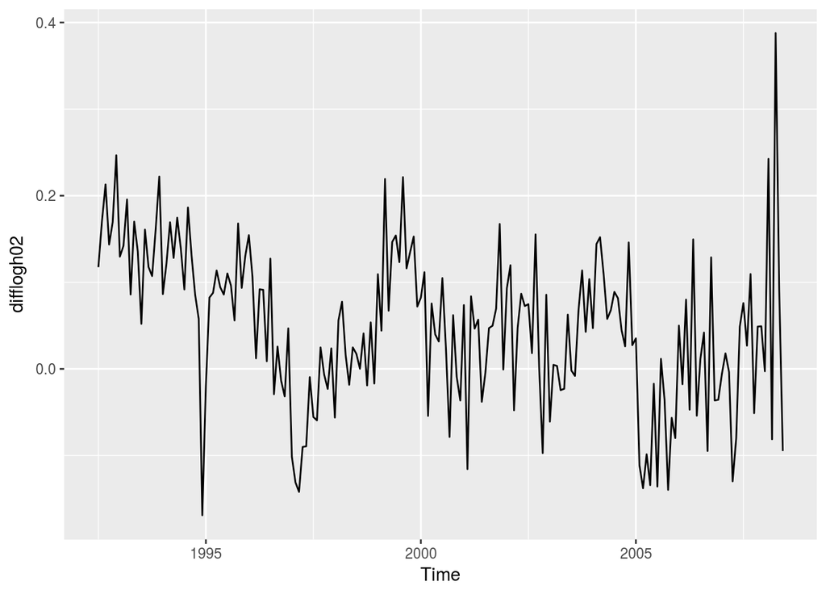

```r
difflogh02 <- diff(log(h02), lag = 12)

autoplot(difflogh02)
```

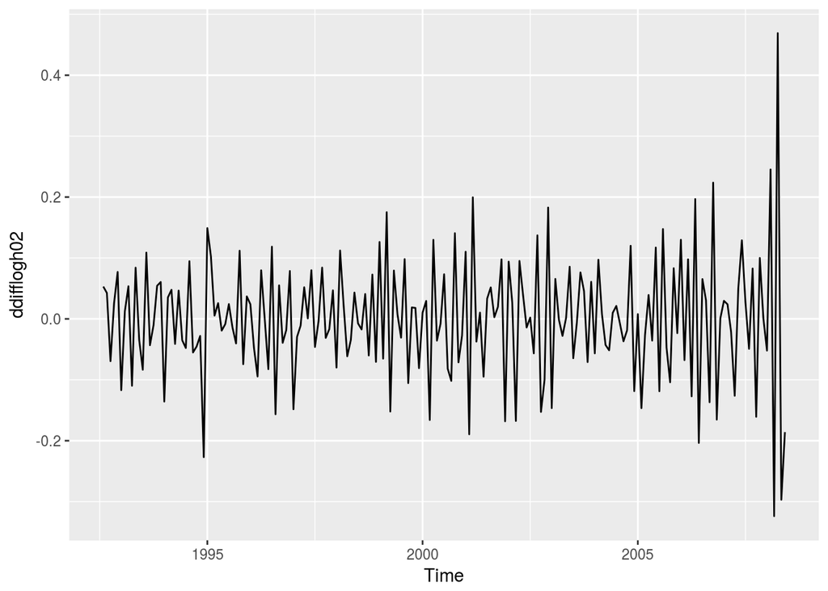

```r
ddifflogh02 <- diff(difflogh02)
autoplot(ddifflogh02)
```

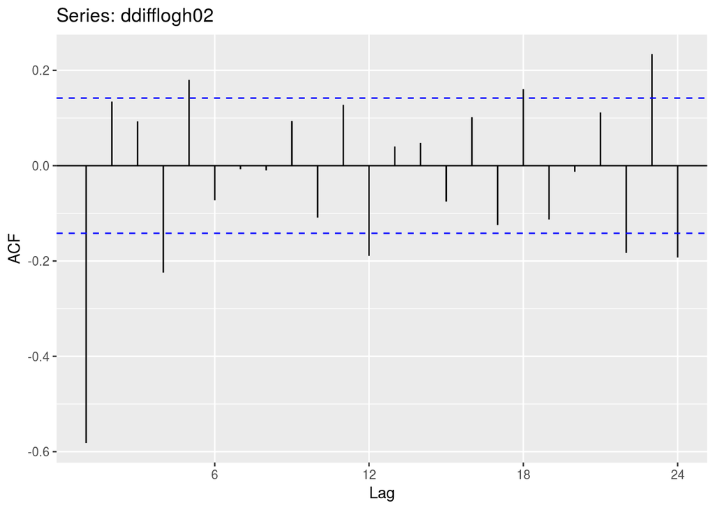

```r
ggAcf(ddifflogh02)
```

## ARIMA models

**A**uto**R**egressive **I**ntegrated **M**oving **A**verage

### AR Models

$y_t = c + \phi_1 y_{t-1} + \phi_2 y_{t-2} + ... + \phi_p y_{t-p} + e_t, e_t \sim \text{white noise}$

Multiple regression with *lagged observations* as predictors

### MA Models

$y_t = c + e_t + \theta_1 e_{t-1} + \theta_2 e_{t-2} + ... + \theta_q e_{t-q}, e_t \sim \text{white noise}$

Multiple regression with *lagged errors* as predictors.

### ARMA Models

$y_t = c + \phi_1 y_{t-1} + ... + \phi_p y_{t-p} + \theta_1 e_{t-1} + ... + \theta_q e_{t-q} + e_t$

Multipel regression with *lagged observations* **and** *lagged errors* as predictors

### ARIMA(p, d, q) Models

Combine ARMA model with d - lots of *differencing*.

To apply an ARIMA you need to decide on a p, d, q and whether to include the constant c.

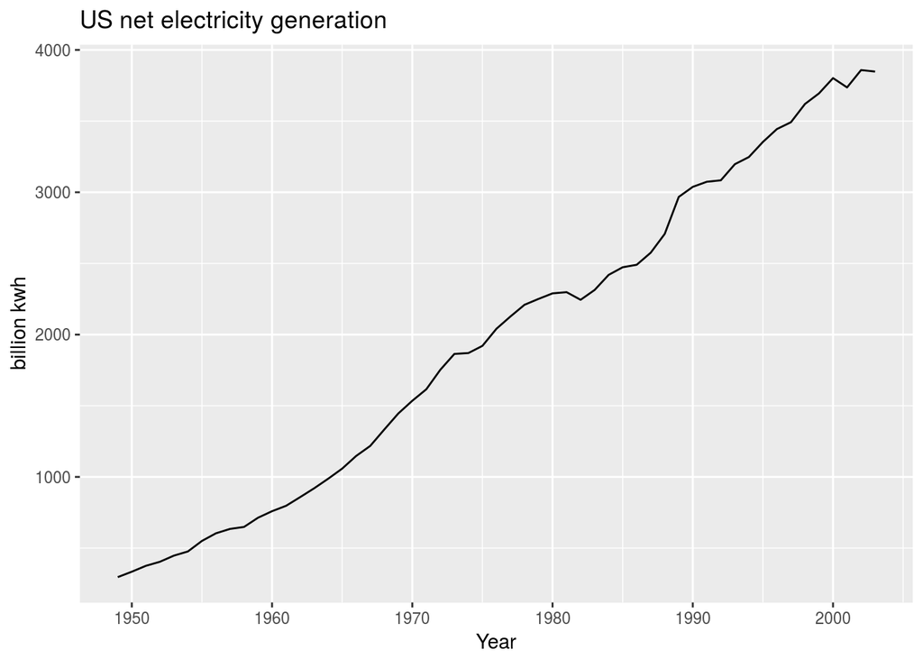

```r
autoplot(usnetelec) +
  xlab("Year") +
  ylab("billion kwh") +
  ggtitle("US net electricity generation")
```

Use the `auto.arima()` function to fit the ARIMA model.

Below we can see it selected **ARIMA(2, 1, 2) with drift**

- 2 past observations
- differenced once
- 2 past errors

**drift** is the term used for the coefficient c on differenced data.

```r
fit = auto.arima(usnetelec)
summary(fit)
```

```
## Series: usnetelec
## ARIMA(2,1,2) with drift
##
## Coefficients:
##           ar1      ar2     ma1     ma2    drift
##       -1.3032  -0.4332  1.5284  0.8340  66.1585
## s.e.   0.2122   0.2084  0.1417  0.1185   7.5595
##
## sigma^2 estimated as 2262:  log likelihood=-283.34
## AIC=578.67   AICc=580.46   BIC=590.61
##
## Training set error measures:
##                      ME     RMSE     MAE        MPE     MAPE      MASE
## Training set 0.04640184 44.89414 32.3328 -0.6177064 2.101204 0.4581279
##                    ACF1
## Training set 0.02249247
```

Like the `ets()` function `auto.arima()` minimized on the AICc value.

**ALSO** you can’t compare AICc values between models with different amounts of differencing.

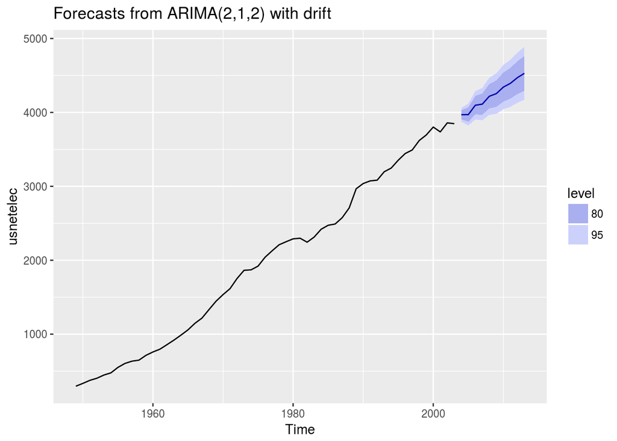

```r
fit %>% forecast() %>% autoplot()
```

`auto.arima()` uses the Hyndman-Khandakar algorithm

- Select number of differences *d* via *unit root tests*
- Select *p* and *q* by minimizing *AICc*
- Estimate parameters using *maximum likelihood estimation*
- Because of the model space size, a stepwise search is used to traverse model space to save time.

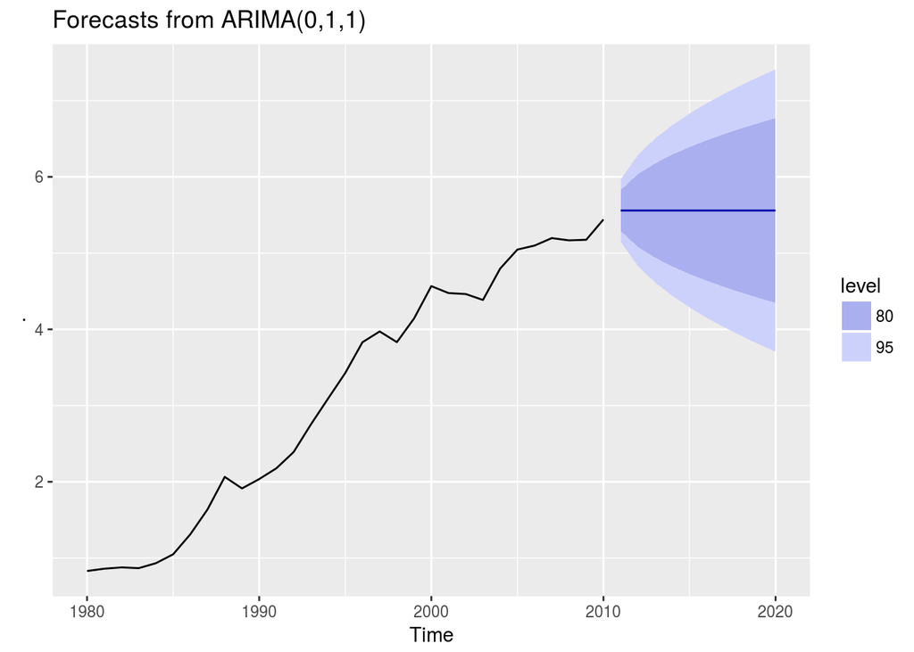

```r
austa %>% Arima(order = c(0,1,1), include.constant = FALSE) %>% forecast() %>% autoplot()
```

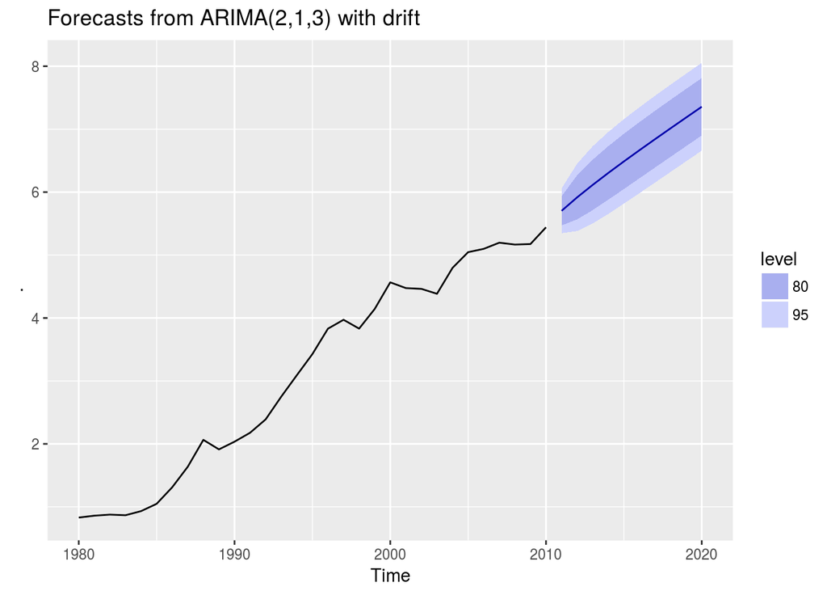

```r
austa %>% Arima(order=c(2,1,3), include.constant=TRUE) %>% forecast() %>% autoplot()
```

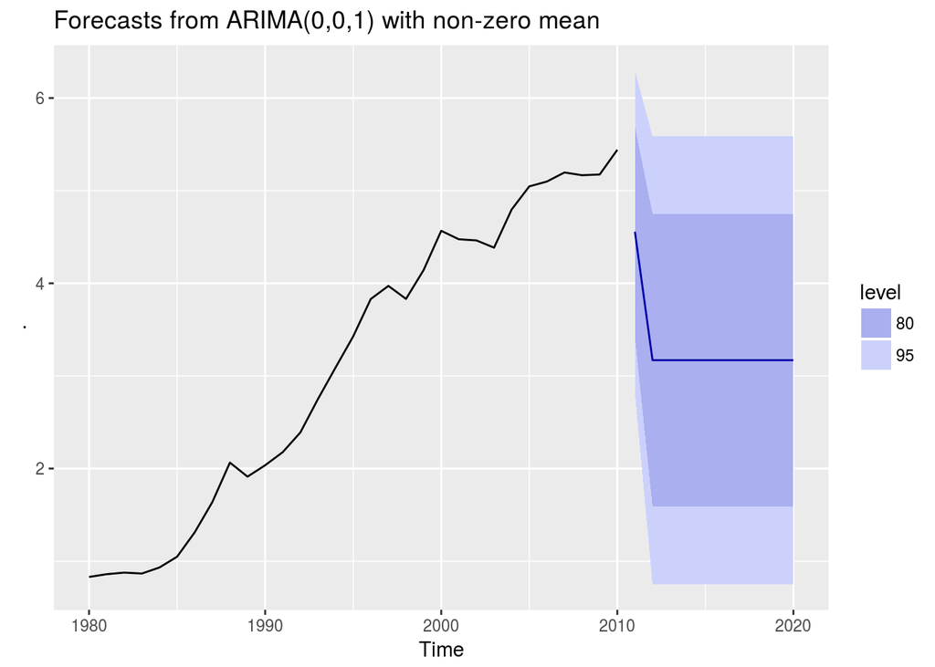

```r
austa %>% Arima(order=c(0,0,1), include.constant=TRUE) %>% forecast() %>% autoplot()
```

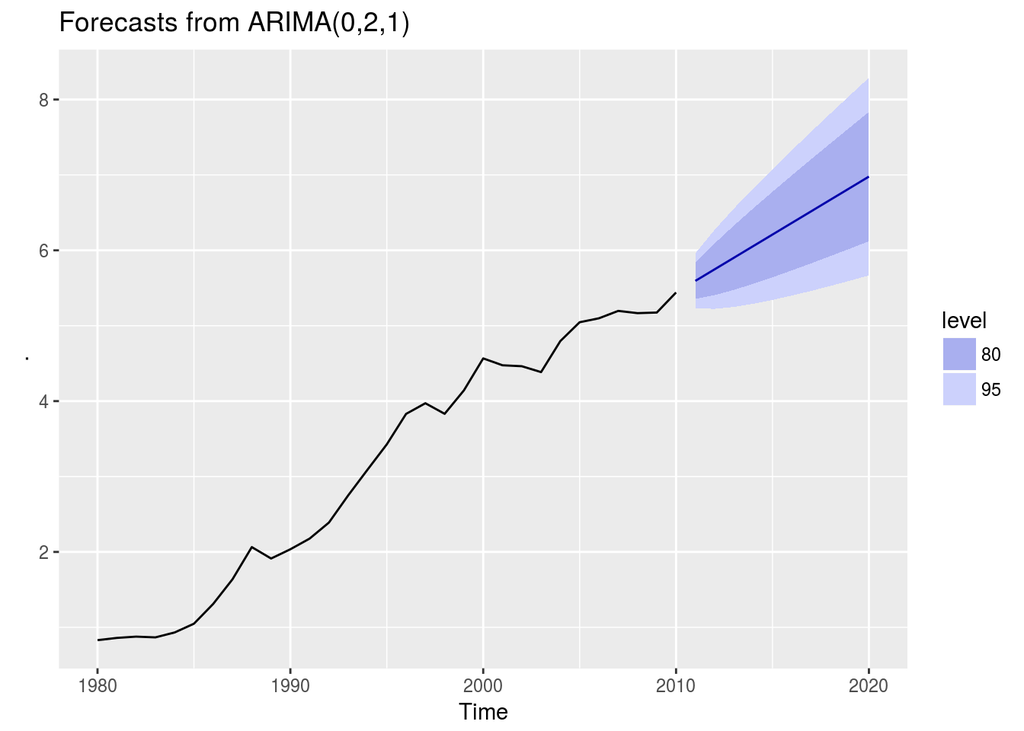

```r
austa %>% Arima(order=c(0,2,1), include.constant=FALSE) %>% forecast() %>% autoplot()
```

### Comparing different model classes

Because **AICc** can not be compared between models of differnet classes (or of the same class with different levels of differencing) we need to use a differnt method. Cross validation works for this `tsCV()`.

Loser MSE is better.

```r
fets <- function(x, h) {
  forecast(ets(x), h = h)
}
farima <- function(x, h) {
  forecast(auto.arima(x), h = h)
}

e1 <- tsCV(austa, fets, h=1)

e2 <- tsCV(austa, farima, h=1)

mean(e1^2, na.rm=TRUE)
```

```
## [1] 0.05661819
```

```r
mean(e2^2, na.rm=TRUE)
```

```
## [1] 0.0413189
```

## Seasonal ARIMA models

Add Seasonal values (P, D, Q)m

- P = seasonal AR lags
- D = Number of seasonal differences
- Q = Number of seasonal MA lags
- m = seasonal period

The resulting equasions are quite complicated and no longer linear as the seasonal and non-seasonal components are multiplied together.

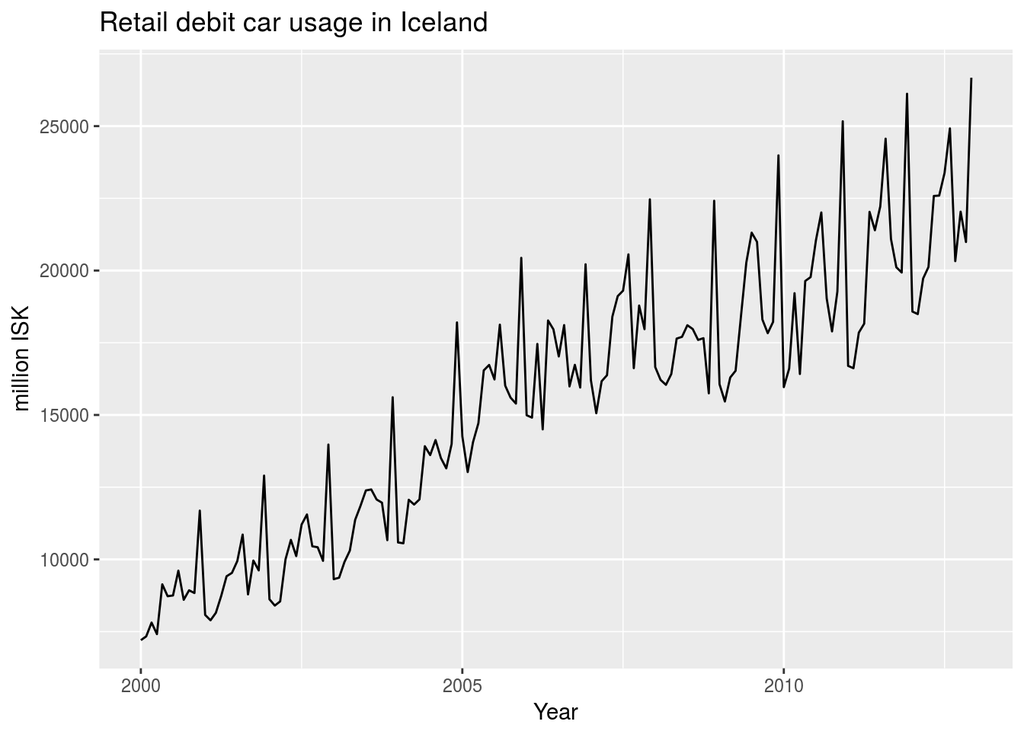

```r
autoplot(debitcards) +
  xlab("Year") +
  ylab("million ISK") +
  ggtitle("Retail debit car usage in Iceland")
```

Because there is varying seasonality over time, the data needs to be **transformed**, setting *lambda=0* will apply the equivolent of a *log()* to the data.

```r
auto.arima(debitcards, lambda=0) -> fit
fit
```

```
## Series: debitcards
## ARIMA(0,1,1)(1,0,0)[12]
## Box Cox transformation: lambda= 0
##
## Coefficients:
##           ma1    sar1
##       -0.6843  0.8747
## s.e.   0.0574  0.0328
##
## sigma^2 estimated as 0.003524:  log likelihood=209.81
## AIC=-413.63   AICc=-413.47   BIC=-404.5
```

**ARIMA(0,1,1)(1,0,0)[12]**

- 1 difference
- 1 MA lag
- 1 seasonal AR lag
- seasonality is 12

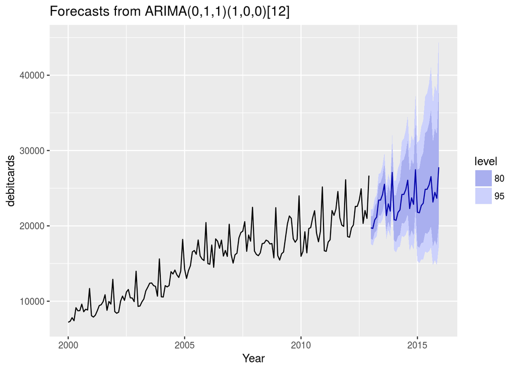

```r
fit %>%
  forecast(h=36) %>%
  autoplot() +
  xlab("Year")
```

The ARIMA models are more sensitive to the seasonal component at the end of the series than at at the beginning.

### General process

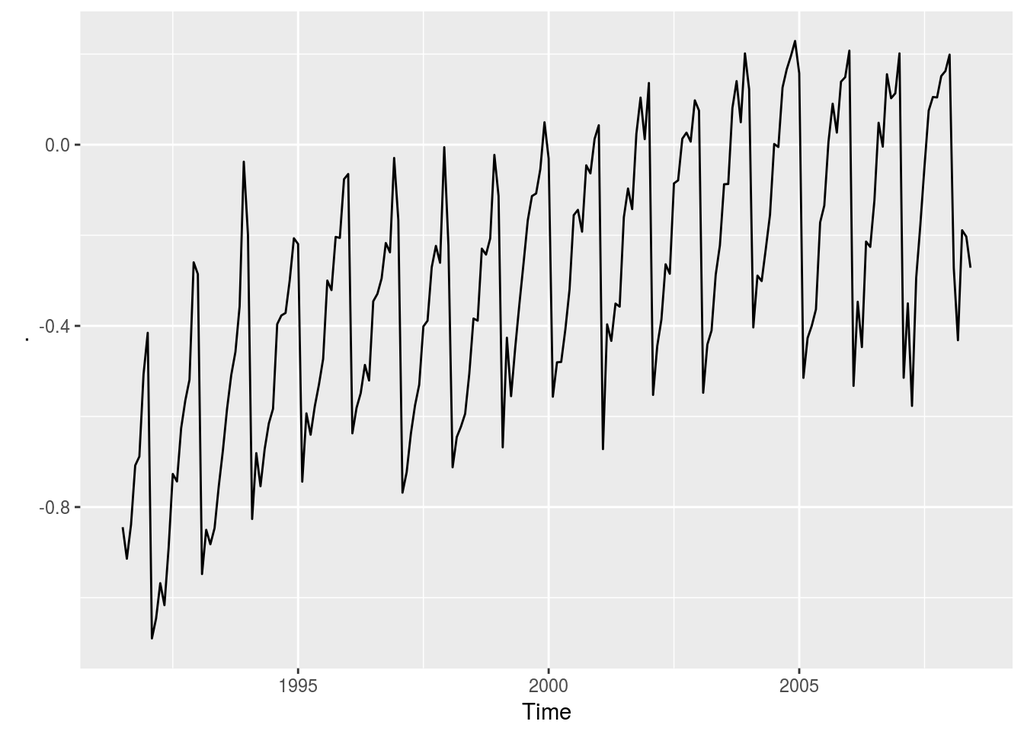

```r
h02 %>% log() %>% autoplot()
```

```r
fit <- auto.arima(h02, lambda=0)

summary(fit)
```

```
## Series: h02
## ARIMA(2,1,3)(0,1,1)[12]
## Box Cox transformation: lambda= 0
##
## Coefficients:
##           ar1      ar2     ma1     ma2      ma3     sma1
##       -1.0194  -0.8351  0.1717  0.2578  -0.4206  -0.6528
## s.e.   0.1648   0.1203  0.2079  0.1177   0.1060   0.0657
##
## sigma^2 estimated as 0.004203:  log likelihood=250.8
## AIC=-487.6   AICc=-486.99   BIC=-464.83
##
## Training set error measures:
##                        ME       RMSE        MAE       MPE    MAPE
## Training set -0.003823286 0.05006017 0.03588577 -0.643286 4.52991
##                   MASE         ACF1
## Training set 0.5919957 -0.007519926
```

Because `auto.arima()` takes short cuts to be as fast as possible, it doesn’t always find the model with the absolute minimum AICc. However, at the expense of performance you can disable the stepwise review to get the model with lowest AICc.

Here’s an example

```r
auto.arima(euretail)
```

```
## Series: euretail
## ARIMA(1,1,2)(0,1,1)[4]
##
## Coefficients:
##          ar1      ma1     ma2     sma1
##       0.7345  -0.4655  0.2162  -0.8413
## s.e.  0.2239   0.1995  0.2096   0.1869
##
## sigma^2 estimated as 0.1592:  log likelihood=-29.69
## AIC=69.37   AICc=70.51   BIC=79.76
```

```r
auto.arima(euretail, stepwise=FALSE)
```

```
## Series: euretail
## ARIMA(0,1,3)(0,1,1)[4]
##
## Coefficients:
##          ma1     ma2     ma3     sma1
##       0.2625  0.3697  0.4194  -0.6615
## s.e.  0.1239  0.1260  0.1296   0.1555
##
## sigma^2 estimated as 0.1564:  log likelihood=-28.7
## AIC=67.4   AICc=68.53   BIC=77.78
```